# Plot the expression of Pi starvaiton induced genes relevant for oxidative stress, in *C. glabrata*

Bin He

2022-04-28 (updated 2022-07-07)

## Goal

Plot the induction of oxidative stress response genes in *C. glabrata* during phosphate starvation. Genes known to be induced during hydrogen peroxide stress in *S. cerevisiae* are the basis for selecting the candiate gene set.

## Data

### *C. glabrata* -Pi time course

Load normalized gene counts for the -Pi time course in *C. glabrata*. Data collected in 2017 by Bin He. Pre-processing was done as described under the E009/seq-results folder.

Below is a simple chart to show the design:

[output not shown]

```r
load("../input/Cgla-Pi-He2017-unpub/E009-Cgla-Pi-time-course-normalized.RData")
cgToSc <- cgToSc %>%
  select(CglaID = cgid, CglaName = cgname, ScerID = scid, ScerName = scname)
anno <- left_join(anno, cgToSc, by = c("GeneID" = "CglaID")) %>%
  select(CglaID = GeneID, CglaName, ScerID, ScerName, Chr, Type.of.Gene)
```

Construct a SummarizedExperiment object

```r
se0 <- SummarizedExperiment(
  assays = lcpm,
  rowData = column_to_rownames(anno, "CglaID"),
  colData = column_to_rownames(sample, "Sample")
  )
# subset the experiment to include just the wt time course
se <- se0[, se0$Genotype == "wt" & se0$Timepoint != "del80"]
```

### *S. cerevisiae* -Pi 1hr gene expression

Description and code below copied/adapted from `uncat-analyses/CTA1-induction-noPi`

*Data source*

| GEO# | Description | Reference |
| --- | --- | --- |
| GSE23580 | Microarray expression analyses of *S. cerevisiae* wt, *pho4∆*, *pho2∆* in rich or no Pi media, sampled at 1hr | Zhou & O’Shea 2011 |

```
Zhou X, O’Shea EK. 2011. Integrated approaches reveal determinants of genome-wide binding and function of the transcription factor Pho4. Mol Cell 42:826–836.
```

The analysis below is inspired by a GEOquery workshop offered by Jason Ratcliff at the Iowa Institute of Human Genetics. `getGEO()` will return an ExpressionSet object, which is then converted into a “SummarizedExperiment” object, which is a more modern data structure that is easier to deal with.

```r
#Sys.setenv("VROOM_CONNECTION_SIZE" = 131072*10) # increase the local cache size
gse <- GEOquery::getGEO(filename = "../input/Scer-Pi-Zhou2011/GSE23580_series_matrix.txt.gz") %>%
  as("SummarizedExperiment")
```

The experimental information is stored in the `colData` fields. The ones we are interested in are:

```r
colData(gse) %>%
  as_tibble() %>%
  filter(grepl("Wild type no vs high Pi conditions", title) | grepl("Comparison 1$", title)) %>%
  select(title, geo_accession, organism = organism_ch1, strain = characteristics_ch1,
         condition_ch1 = characteristics_ch1.2, label_ch1, condition_ch2 = characteristics_ch2.2, label_ch2)
```

| title | geo_accession | organism | strain | condition_ch1 | label_ch1 | condition_ch2 | label_ch2 |
| --- | --- | --- | --- | --- | --- | --- | --- |
| Mutant Cycle Replicate 1 Comparison 1 | GSM578408 | Saccharomyces cerevisiae | strain: K699 | protocol: No Pi (0 mM Pi) | Cy3 | protocol: High Pi (10 mM Pi) | cy5 |
| Mutant Cycle Replicate 2 Comparison 1 | GSM578424 | Saccharomyces cerevisiae | strain: K699 | protocol: No Pi (0 mM Pi) | Cy3 | protocol: High Pi (10 mM Pi) | cy5 |
| Mutant Cycle Replicate 3 Comparison 1 | GSM578440 | Saccharomyces cerevisiae | strain: K699 | protocol: No Pi (0 mM Pi) | Cy3 | protocol: High Pi (10 mM Pi) | cy5 |
| Wild type no vs high Pi conditions Replicate 1 | GSM578456 | Saccharomyces cerevisiae | strain: K699 | protocol: High Pi (10 mM Pi) | Cy3,Cy5 | protocol: No Pi (0 mM Pi) | Cy5,Cy3 |
| Wild type no vs high Pi conditions Replicate 2 | GSM578457 | Saccharomyces cerevisiae | strain: K699 | protocol: High Pi (10 mM Pi) | Cy3,Cy5 | protocol: No Pi (0 mM Pi) | Cy5,Cy3 |
| Wild type no vs high Pi conditions Replicate 3 | GSM578458 | Saccharomyces cerevisiae | strain: K699 | protocol: High Pi (10 mM Pi) | Cy3,Cy5 | protocol: No Pi (0 mM Pi) | Cy5,Cy3 |
| Wild type no vs high Pi conditions Replicate 4 | GSM578459 | Saccharomyces cerevisiae | strain: K699 | protocol: High Pi (10 mM Pi) | Cy3,Cy5 | protocol: No Pi (0 mM Pi) | Cy5,Cy3 |

The first three are part of the mutant cycle while the latter four are not. The latter four are said to have incorporated a dye swap, although I can’t tell how the swap was done from the table above.

Separately extract the two subsets and examine them separately.

```r
gse1 <- gse[, grepl("Comparison 1$", gse$title)]
gse2 <- gse[, grepl("Wild type no vs high Pi conditions", gse$title)]
```

### OSR gene list based on *S. cerevisiae* literature

Compile gene list known to be involved in the response to hydrogen perxoide. This list is mostly based on Lee *et al.* 1999 (PMID: 10347154) and Hasan *et al.* 2002 (PMID: 12100562)

```r
# manually compiled datasets
scer.osr <- read_csv("../input/gene-list/s-cerevisiae-hydroperoxide-response-genes.csv", col_types = cols()) %>%
  mutate(ori.name = str_to_upper(ori.name), cor.name = str_to_upper(cor.name))
# these IDs are retrieved from YeastMine
scer.id <- read_csv("../input/gene-list/s-cerevisiae-hydroperoxide-response-gene-id.csv", col_types = cols()) %>%
  mutate(input = str_to_upper(input))
# merge
scer.osr <- scer.id %>%
  select(input, scer.sys = secondaryIdentifier, fun = name, length) %>%
  left_join(scer.osr, by = c("input" = "cor.name")) %>%
  select(scer.common = input, -ori.name, everything())
```

### Mapping between the two genomes

Mapping between the two species are downloaded from CGD. Two types of mappings are available: [orthology](http://www.candidagenome.org/download/homology/orthologs/) is based on the [Yeast Gene Order Browser](http://ygob.ucd.ie/); [best hits](http://www.candidagenome.org/download/homology/best_hits/) is based on `blastp` and is only performed for genes lacking a credible ortholog. Note that because both mappings start from *C. glabrata*, they are not the ideal mapping to use for identifying the *C. glabrata* ortholog for *S. cerevisiae* genes, but should be sufficient for the current purpose. This is because most of the genes do have 1-to-1 orthologs between the two species and thus starting from either species should yield the same mapping.

Below our goal is to reverse-engineer an scToCg one-to-one mapping from the two cgToSc mappings.

```r
# cgToSc is loaded already and stores the orthology mapping
# read the best hit mapping
cgToSc.bh <- read_tsv("../input/annotation/C_glabrata_CBS138_S_cerevisiae_best_hits.txt",
                           comment = "#", col_types = cols(),
                           col_names = c("CglaID","CglaName","Cgla.id","ScerID","ScerName","Scer.id")) %>%
  select(CglaID, CglaName, ScerID, ScerName)
re.scToCg <- bind_rows(
  ortholog = cgToSc,
  # only include the rows in the best hit table if the Scer gene is not already in the orthology mapping
  # for Scer genes with more than one Cgla genes mapped to it by blastp, randomly pick the first one
  `best hit` = cgToSc.bh %>% filter(!ScerID %in% cgToSc$ScerID) %>% group_by(ScerID) %>% filter(row_number() == 1),
  .id = "mapping")
```

Combine the orthology and best hits mapping

```r
cgla.list <- scer.osr %>%
  dplyr::rename(ScerID = scer.sys, ScerName = scer.common) %>%
  left_join(cgToSc %>% select(CglaID.or = CglaID, CglaName.or = CglaName, ScerID, ScerName)) %>%
  # note that the following is not a robust procedure. it just happens that none of the Scer genes in
  # scer.osr have more than one best hit mapped Cgla genes
  left_join(cgToSc.bh %>% select(CglaID.bh = CglaID, CglaName.bh = CglaName, ScerID, ScerName)) %>%
  mutate(
    CglaID = ifelse(is.na(CglaID.or), CglaID.bh, CglaID.or),
    CglaName = ifelse(is.na(CglaName.or), CglaName.bh, CglaName.or)
  ) %>%
  select(starts_with("Cgla"), everything())
```

## Analysis

### Plotting *C. glabrata* time course

```r
myGenesPlot <- function(genes = "CAGL0B02475g", names = "PMU2") {
  # this function takes in the read count matrix (normalized and transformed) and a list of gene IDs
  # and plots the values stratified by genotype and timepoint
  if(any(!genes %in% rownames(se))){
    print("The following genes are not included in the experiment. Check to make sure that the gene names are correct.")
    setdiff(genes, rownames(se))
    stop("Gene names not included in the experiment")
  }

  if(!is.null(names(genes))){
    names = names(genes)
  }
  else if(length(genes) != length(names)){
    stop("length of 'genes' must equal length of 'names'")
  }


  # construct tibble for plotting
  dat <- t(assay(se[genes,])) %>% as_tibble(rownames = NA) %>% rownames_to_column(var = "sample") # subset the expression matrix
  tb <- colData(se) %>% as_tibble(rownames = NA) %>%
    rownames_to_column(var = "sample") %>%
    select(sample, Genotype, Timepoint) %>%
    left_join(dat, by = "sample") %>%
    pivot_longer(cols = starts_with("CAGL"), names_to = "gene", values_to = "log2 cpm") %>%
    left_join(tibble(gene = genes, name = names), by = "gene")

  p <- ggplot(tb, aes(x = Timepoint, y = `log2 cpm`)) +
    geom_point() + geom_smooth(method = "loess", formula = y ~ x, aes(x = as.numeric(Timepoint), y = `log2 cpm`)) +
    xlab("") + ylab("log2 count per million") + facet_wrap(~paste(gene, name, sep = ":"), scale = "free_y") +
    theme_bw(base_size = 12) +
    theme(axis.text.x = element_text(angle = 45, size = rel(0.75), hjust = 1),
          axis.text.y = element_text(size = rel(0.75)))
  return(p)
}
```

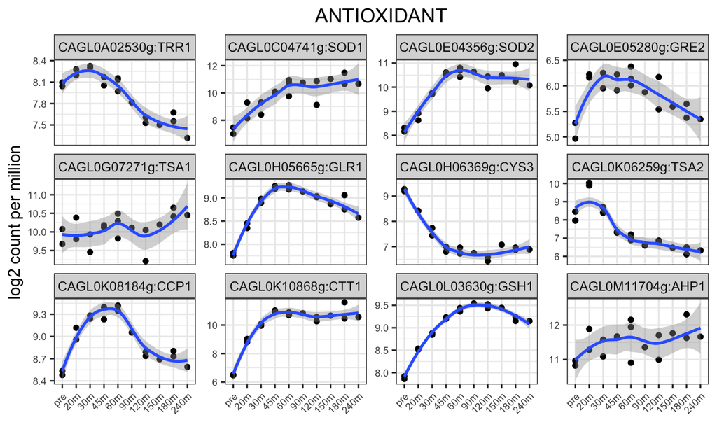

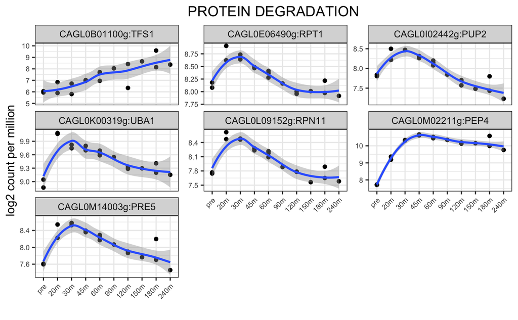

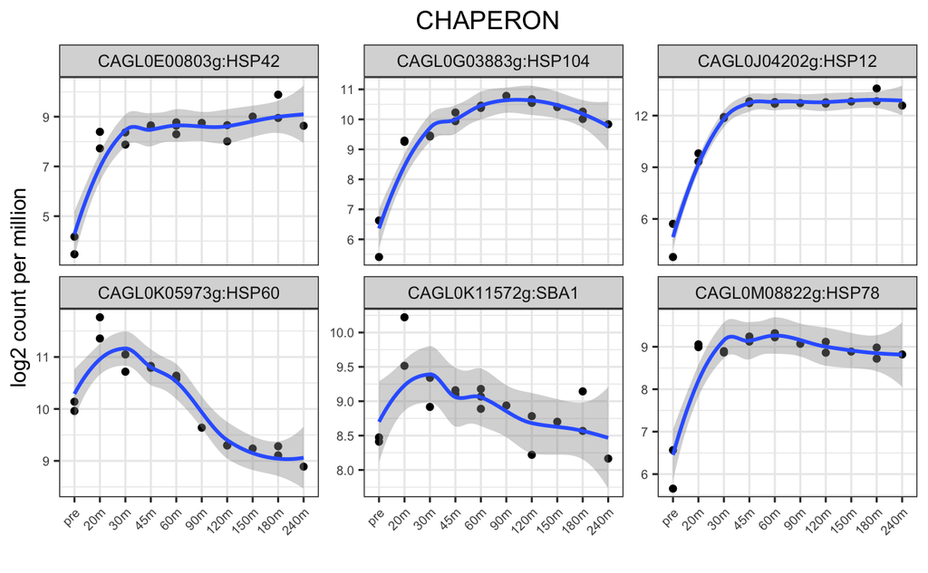

```r
group <- c("antioxidant", "protein degradation", "chaperon")
categories <- lapply(group, function(x){
  test <- cgla.list %>%
    filter(category == x) %>%
    select(ScerName, CglaID) %>%
    filter(!is.na(CglaID)) %>%
    deframe()
})
names(categories) <- group
categories$antioxidant <- c(categories$antioxidant, CTT1 = "CAGL0K10868g", TSA2 = "CAGL0K06259g")
for (i in seq_along(categories)){
  p <- myGenesPlot(categories[[i]])
  print(p + ggtitle(str_to_upper(group[i])) + theme(plot.title = element_text(hjust = 0.5)))
}
```

### Plotting *S. cerevisiae* -Pi at 1hr

First, we need to assemble the dataset. The idea is to calculate the log2FC between 1hr and pre-stress time points from the *C. glabrata* dataset. Later we will merge it with the *S. cerevisiae* data. The final data should include `Species | Name | ID | log2FC`, in which `Name` is always from *S. cerevisiae* and `ID` from the respective species.

```r
tmp <- assay(se[, se$Timepoint %in% c("pre", "60m")])
colnames(tmp) <- c("pre.1","pre.2","60m.1","60m.2","60m.3")
cgla.1hr <- as_tibble(tmp, rownames = "CglaID") %>%
  mutate(
    base = (pre.1 + pre.2)/2,
    m60.1 = `60m.1` - base,
    m60.2 = `60m.2` - base,
    m60.3 = `60m.3` - base
  ) %>%
  select(CglaID, starts_with("m60")) %>%
  pivot_longer(m60.1:m60.3, names_to = NULL, values_to = "log2FC")
```

With the Cgla data calculated, we can write a function that takes a list of *S. cerevisiae* gene names as input and plot the logFC in both species.

```r
myCompare <- function(genes = "YML123C"){
  # check gene names against the S. cerevisiae microarray annotation
  scerArray <- rowData(gse)$ORF
  names(scerArray) <- rowData(gse)$Name
  if(all(!genes %in% scerArray)){
    stop("Check ORF names. None are present in the annotation file.")
  }else if(any(!genes %in% scerArray)){
    print("The following S. cerevisiae genes are not included on the microarray chip.")
    print(setdiff(genes, scerArray))
  }else if(any(!genes %in% re.scToCg$ScerID)){
    # additionally check if the genes have a C. glabrata ortholog
    print("The following S. cerevisiae genes do not have a C. glabrata ortholog.")
    print(setdiff(genes, re.scToCg$ScerID))
  }
  # construct a gene set tibble that includes orthologous gene names in both species
  geneSet <- rowData(gse) %>%
    as_tibble(rownames = NULL) %>%
    filter(ORF %in% genes) %>%
    select(ScerID = ORF) %>%
    inner_join(re.scToCg, by = "ScerID")

  # extract Scer data
  probes <- rowData(gse1) %>% as_tibble() %>% filter(ORF %in% geneSet$ScerID) %>% select(ID, ORF)
  scerDat <- assay(gse1)[probes$ID,,drop=FALSE] %>%
    as_tibble(rownames = "ID") %>%
    left_join(probes, by = "ID") %>%
    pivot_longer(cols = starts_with("GSM"), names_to = NULL, values_to = "log2FC") %>%
    select(ScerID = ORF, log2FC) %>%
    left_join(select(geneSet, ScerID, ScerName), by = "ScerID") %>%
    select(ScerName, ID = ScerID, log2FC)
  # extract Cgla data
  cglaDat <- cgla.1hr %>%
    filter(CglaID %in% na.omit(geneSet$CglaID)) %>%
    left_join(select(geneSet, CglaID, ScerName), by = "CglaID") %>%
    select(ScerName, ID = CglaID, log2FC)
  Dat <- bind_rows(`S. cerevisiae` = scerDat, `C. glabrata` = cglaDat, .id = "species") %>%
    # sort the gene list by Cgla induction mean
    mutate(ScerName = forcats::fct_reorder(ScerName, log2FC, mean, .desc = TRUE))

  # plotting
  p <- ggplot(Dat, aes(x = ScerName, y = log2FC, group = species)) +
    geom_bar(aes(fill = species), stat = "summary", fun = "mean", alpha = 0.9,
             position = position_dodge(0.9)) +
    geom_point(aes(color = species), position = position_dodge(0.9), size = 1) +
    geom_hline(yintercept = 0, linetype = 1, color = "gray20") +
    geom_hline(yintercept = 1, linetype = 2, color = "gray50") +
    scale_color_manual(values = c("S. cerevisiae" = "gray30", "C. glabrata" = "orange2"), guide = NULL) +
    scale_fill_manual("Species", values = c("S. cerevisiae" = "yellowgreen", "C. glabrata" = "royalblue3")) +
    labs(x = expression(paste(italic("S. cerevisiae"), " gene names")),
         y = "log2 Fold Change") +
    #coord_flip() +
    theme_bw(base_size = 12) +
    theme(legend.text = element_text(face = 3),
          legend.position = c(0.8, 0.8)) +
    background_grid(major = "y", minor = "none")
  return(p)
}
```

```
[1] "antioxidant"
[1] "The following S. cerevisiae genes do not have a C. glabrata ortholog."
[1] "YGR088W" "YBR117C" "YCL035C" "YGR209C"
[1] "protein degradation"
[1] "chaperon"
[1] "The following S. cerevisiae genes do not have a C. glabrata ortholog."
[1] "YPL240C" "YAL005C"
[1] "TF"
```

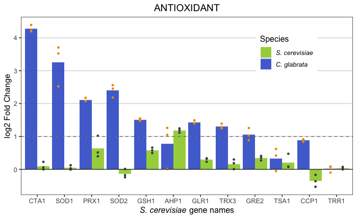

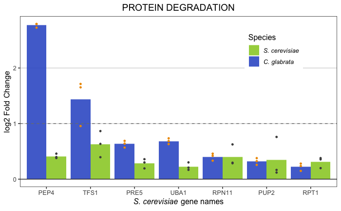

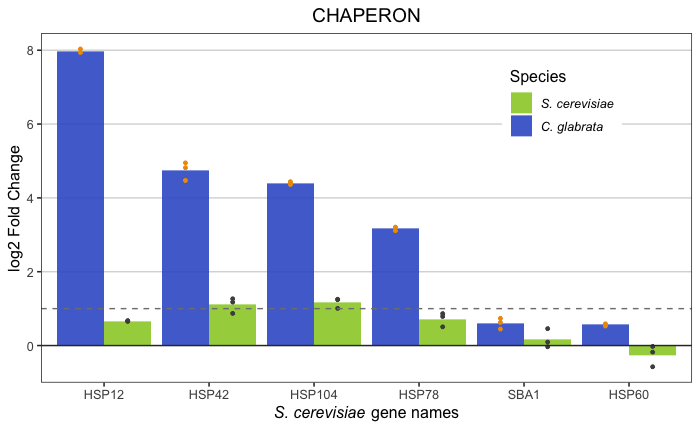

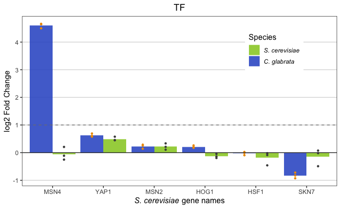

Plot for the grant, combining antioxidant and TF

```r
# add a fourth category, namely TFs with known roles in oxidative stress response
list.TF <- c(YAP1 = "YML007W", SKN7 = "YHR206W", MSN2 = "YMR037C", MSN4 = "YKL062W")
Dat <- bind_rows(
  list(
    Antioxidant = myCompare(geneList$antioxidant)$data,
    TF = myCompare(list.TF)$data
  ),
  .id = "category"
)
```

```
[1] "The following S. cerevisiae genes do not have a C. glabrata ortholog."
[1] "YGR088W" "YBR117C" "YCL035C" "YGR209C"
```

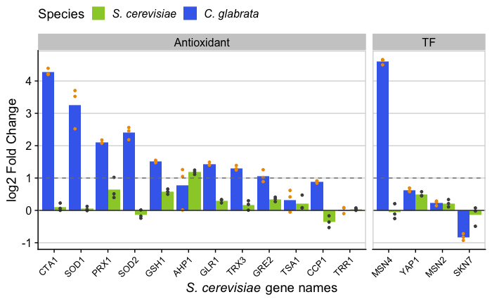

```r
ggplot(Dat, aes(x = ScerName, y = log2FC, group = species)) +
    geom_bar(aes(fill = species), stat = "summary", fun = "mean",
             position = position_dodge(0.9)) +
    geom_point(aes(color = species), position = position_dodge(0.9), size = 1) +
    geom_hline(yintercept = 0, linetype = 1, color = "gray20") +
    geom_hline(yintercept = 1, linetype = 2, color = "gray50") +
    scale_color_manual(values = c("S. cerevisiae" = "gray30", "C. glabrata" = "orange2"), guide = NULL) +
    scale_fill_manual("Species", values = c("S. cerevisiae" = "yellowgreen", "C. glabrata" = "royalblue2")) +
    labs(x = expression(paste(italic("S. cerevisiae"), " gene names")),
         y = "log2 Fold Change") +
    facet_grid(.~category, space = "free_x", scales = "free_x") +
    theme_cowplot() + panel_border() +
    theme(axis.text.x = element_text(angle = 45, hjust = 1, size = rel(0.8)),
          legend.text = element_text(face = 3), legend.position = "top") +
    background_grid(major = "y", minor = "none")
ggsave(paste0("../output/", gsub("-", "", Sys.Date()), "-antioxidant-TF-for-grant.pdf"), width = 6, height = 4)
```